# 통계 방법론1 중간대체

## 실습 17. 분산 분석

- depth.etch.csv
- 다음은 새로운 식각 방법(method)들에 대하여 조사된 특정 위치의 깊이(depth)이다.
- 식긱 방법 중 Control은 현재 사용하는 방법이며, (A1, A2)는 세정액의 서로 다른 배합 그리고 (B1, B2)는 가스 노출 시간을 서로 다르게 지정한 것이다.
- 가장 큰 식각 깊이를 제공하는 방법을 선택하고자 한다.
- 데이터 불러오기

```r
etch <- read.csv(paste0(data_path, "depth.etch.csv"))
str(etch)
```

```
## 'data.frame':    225 obs. of  2 variables:
##  $ method: chr  "A1" "A1" "A1" "A1" ...
##  $ depth : num  80 57.4 83.6 62.8 53.6 ...
```

- 데이터는 총 225개의 관측치와 2개의 변수로 구성
  - **`method`:** 식각 방법을 나타내는 문자열 변수
  - **`depth`:** 해당 방법으로 식각했을 때의 깊이를 나타내는 숫자형 변수
- 데이터 확인

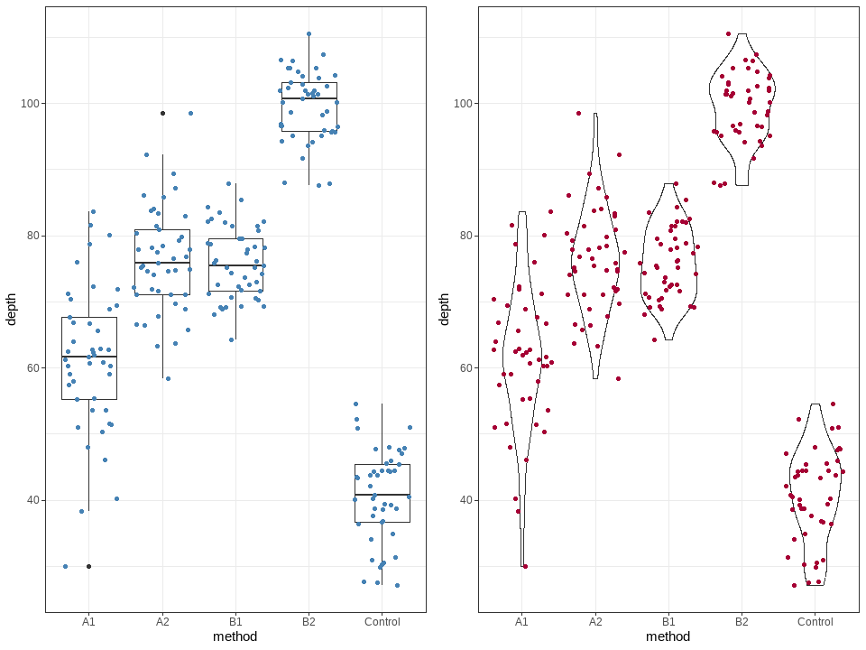

```r
g1 <- etch %>%
  ggplot(aes(x = method, y = depth)) +
  geom_boxplot() +
  geom_jitter(color = sbl) +
  theme_bw()

g2 <- etch %>%
  ggplot(aes(x = method, y = depth)) +
  geom_violin() +
  geom_jitter(color = lre) +
  theme_bw()
gridExtra::grid.arrange(g1, g2, ncol = 2)
```

- ANOVA 진행

```r
model <- aov(depth ~ method, data = etch)
summary(model)
```

```
##              Df Sum Sq Mean Sq F value              Pr(>F)
## method        4  84764   21191     360 <0.0000000000000002 ***
## Residuals   220  12961      59
## ---
## Signif. codes:  0 '***' 0.001 '**' 0.01 '*' 0.05 '.' 0.1 ' ' 1
```

- p-value = 0.0000000000000002 < 0.05 이므로 $H_{0}$를 기각한다.
  - 따라서 고려된 식각 방법이 모두 동일하지는 않다.
- 수준 별 요약값 정리

```r
model.tables(model, tpye = "means", se = TRUE)
```

```
## Tables of effects
##
##  method
## method
##      A1      A2      B1      B2 Control
##   -9.54    5.66    5.12   28.83  -30.06
##
## Standard errors of effects
##         method
##          1.144
## replic.     45
```

- 각 방법의 효과의 크기를 나타낸다.
  - `Control` 방법은 전체 평균보다 약 30.06만큼 낮은 것을 알 수 있다.
  - `B2` 방법은 전체 평균보다 약 28.83보다 높은 것을 알 수 있다.
    - 따라서 `B2’ 방법이 가장 깊은 식각을 제공한다.
- 잔차 진단

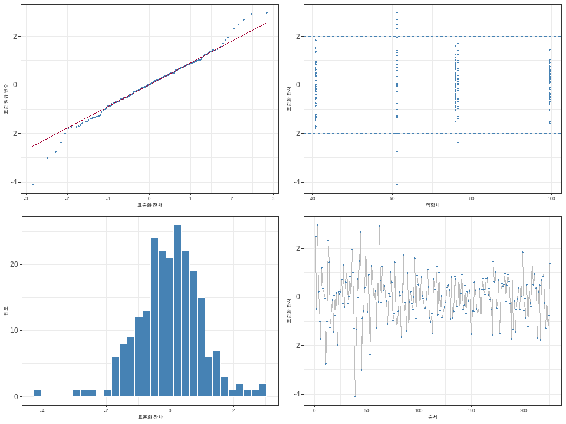

```r
etch$res <- resid(model)
etch$rsd <- rstandard(model)
etch$fit <- fitted.values(model)
m_residuals(etch)
```

- Quantile-Quantile (Q-Q) 그래프 (왼쪽 상단 그래프)
  - 잔차가 정규 분포를 따른다면 점들이 직선을 이루게 된다.
  - 대부분의 점들이 빨간선 주변에 위치하고 있다. 하지만 극단값에서는 라인에서 약간 벗어나 있다.
    - 따라서 꼬리 부분에서 이상치의 가능성이 있다.
- 잔차 vs 예측값 그래프 (오른쪽 상단 그래프)
  - 일정한 주기로 반복되는 패턴을 보인다.
- 잔차의 히스토그램 (왼쪽 하단 그래프)
  - 대체로 히스토그램의 종 모양에 가깝다.
- 잔차 vs 순서 그래프 (오른쪽 하단 그래프)
  - 잔차의 변동성이 커보인다.
- 표준화 잔차의 정규성 진단

```r
ad.test(etch$rsd)
```

```
##
##  Anderson-Darling normality test
##
## data:  etch$rsd
## A = 0.7, p-value = 0.08
```

# 선형 회귀 분석

Linear Regression Analysis

- 회귀 계수는 통계량이다.
- 회귀 분석은 알려져 있지 않은 f(x)를 대상으로 적용된다.
- 모수 절약(Parsimony)의 원칙 하에서 과현상에 대한 해석력(Interpretation)을 확보해야 한다.
- 선형 회귀 분석 Linear Regression Analysis
  - **동시**에 측정했을 때 사용**(같은 공간, 시간일 때)**
- y: **반응 변수(response)**, 종속 변수
- x: **설명 변수(exploratory variable(s))**, 예측 변수, 독립변수

# 4. 단순 회귀 분석

Simple Regression Analysis

$$y_i = \beta_0 + \beta_1x_i + \varepsilon_i \quad (i =
1,2,...,n),~~\varepsilon_i \sim iid \ N(0,\sigma^2)$$

- 오차는 상호 독립이다.
- 오차는 정규 분포(normal distribution)를 따른다.
- 오차는 모든 설명 변수의 값에 대하여 분산 $\sigma^2$가 같다.
  - iid; independently identically distributed
- 데이터를 이용한 회귀 계수(들)와 분산의 추정

$$(x_i,y_i), \ i = 1,2,...,n \rightarrow (\beta_0, \beta_1, \sigma^2)$$

- 추정된 회귀식(estimated regression equation)
  - $\hat{y} = y_0$은 평균 반응(mean response)으로 해석
  - 고려된 데이터의 범위 내에서 적용

$$\hat{y} = \beta_0 + \beta_1x_i,~~~x \in [x_{min}, x_{max}]$$

- $i$th 잔차(residual); $\varepsilon_i$
  - 가정된 모형 하에서 오차의 추정값
  - 관측값 $y_i$와 추정된 회귀선 $\hat{y}_i$의 차이

$$\varepsilon_i = y_i - \hat{y}_i = y_i - (\beta_0 + \beta_1x_i), \quad (i
= 1,2,...,n)$$

## 4.1. 회귀 계수의 추정: 최소 제곱법

Method of Least Squares

$$\arg \min_{\beta_0, \beta_1} L(\beta_0,
\beta_1) = \sum_{i=1}^{n} (y_i - \beta_0 - \beta_1 x_i)^2$$

- 최소 제곱 추정량(LSE)

$$\hat{\beta}_0 = \bar{y} - \hat{\beta}_1
\bar{x}$$
$$\hat{\beta}_1 =
\frac{S_{xy}}{S_{xx}}$$

여기서,

$$S_{xx} = \sum_{i=1}^{n} (x_i -
\bar{x})^2$$
$$S_{xy} = \sum_{i=1}^{n}
(y_i - \bar{y})(x_i - \bar{x})$$

- LSE의 통계적 특성

$$E(\hat{\beta}_0) = \beta_0, \quad
Var(\hat{\beta}_0) = \sigma^2 \left( \frac{1}{n} +
\frac{\bar{x}^2}{S_{xx}} \right)$$
$$E(\hat{\beta}_1) = \beta_1, \quad
Var(\hat{\beta}_1) = \frac{\sigma^2}{S_{xx}}$$

## 4.2. 잔차

residuals

- 잔차에는 설명 가능한 특정 패턴이 남아 있지 않아야 한다.

## 4.3. 변동의 분해

decompostion of variations

- 적합한 $R^2$를 판단하기 위한 통계적 기준값은 없다.
  - ex) 0.64이상
- 결정 계수만으로 올바른 회귀 모형을 결정할 수 없다.

## 4.4. 회귀 계수의 유의성 검정

- 일반적으로 $\beta_0$의 유의성 검정 결과는 고려하지 않는다.
- $\beta_0 = 0$을 적용한 경우를 원점을 통과하는 회귀 모형이라고 한다.
- $\beta_1$의 유의성 검정 결과는 가정된 모형의 타당성에 종속된다.

## 4.5. 추정된 회귀식의 활용

- 예측 구간(prediction interval)은 항상 신뢰 구간(confidence interval)보다 넓거나 같다.
- 만일 일정 범위에서 가능한 모든 x 값에 대하여 구해진 신뢰구간과 예측 구간을 각각 신뢰대(confidence bands) 그리고 예측대(prediction bands)라고 부른다.

## 실습 17. 임의로 선택된 소형 화물의 무게$(x;~g)$과 부피$(y;~cm^3)$

- 예제1 simple.csv
- 무게에 의하여 운송 요금을 결정하는 소형 화물들 중에서 임의로 선택된 58개의 무게(x; weight)과 부피(y; volume)을 조사하였다.
- 이를 이용하여 중량과 부피간의 관계를 추정하여 운송 계획을 수립하고자 한다.
- 데이터 불러오기 및 확인

```r
cargo <- read.csv(paste0(data_path, "simple.csv"))
str(cargo)
```

```
## 'data.frame':    58 obs. of  3 variables:
##  $ x : num  80.9 84.2 127.2 78.9 95.5 ...
##  $ y : num  2070 2799 4021 2496 2478 ...
##  $ hy: num  2358 2465 3824 2295 2820 ...
```

- 결측값 확인

```r
na_count(cargo)
```

```
##  x  y hy
##  0  0  0
```

- 세 개의 변수 모두 결측값이 없다.
- LS 추정량 계산
  - **round(x, digits = k)**는 유효 숫자를 소수점 k번째로 반올림한다.

```r
x <- cargo$x
y <- cargo$y
Sxy <- sum((x - mean(x)) * (y - mean(y)))
Sxx <- sum((x - mean(x))^2)
Syy <- sum((y - mean(y))^2)
#
hat_beta1 <- Sxy / Sxx
hat_beta0 <- mean(y) - hat_beta1*mean(x)
round(c(hat_beta0, hat_beta1), 2)
```

```
## [1] -204.1   31.7
```

- 추정된 회귀 계수 $\hat\beta_0 = -204.1$ 그리고 $\hat\beta_1=31.7$로 계산되었다.
- simple_reg()함수를 통한 분석

```r
simple_reg(cargo, x, y)
```

```
##  x  y hy
##  0  0  0
##
## Call:
## lm(formula = y ~ x, data = data)
##
## Residuals:
##    Min     1Q Median     3Q    Max
## -930.9 -293.1   10.2  200.2 1000.0
##
## Coefficients:
##             Estimate Std. Error t value           Pr(>|t|)
## (Intercept)   -204.1      289.9    -0.7               0.48
## x               31.7        2.9    10.9 0.0000000000000016 ***
## ---
## Signif. codes:  0 '***' 0.001 '**' 0.01 '*' 0.05 '.' 0.1 ' ' 1
##
## Residual standard error: 409 on 56 degrees of freedom
## Multiple R-squared:  0.681,  Adjusted R-squared:  0.675
## F-statistic:  120 on 1 and 56 DF,  p-value: 0.00000000000000162
```

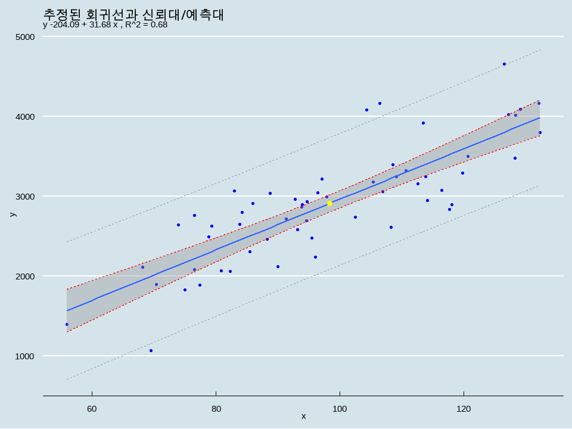

- 결측치는 존재하지 않는다.
- 결정계수값은 0.68로 잘 적합하고 있다고 볼 수 있다.
- p-value = 0.00000000000000162 < $\alpha = 0.05$ 이므로 $H_{0}$를 기각하므로 통계적으로 유의하다.
  - 따라서 위 회귀모형은 적절하다.
- 신뢰대는 빨간색 점선으로 이루어져 있다.
  - 노란색으로 색칠된 데이터가 위 데이터의 평균을 의미하고 평균을 기준으로 95%에 대한 신뢰구간이다.
- 예측대를 확인해봤을 때 일부 이상치가 있는 것으로 보인다.

## 실습 18. 유통 매장 정리 시간

```r
dist <- read.csv(paste0(data_path, "dist.store.csv"))
```

- 데이터 확인

```r
str(dist)
```

```
## 'data.frame':    25 obs. of  3 variables:
##  $ Time    : num  16.7 11.5 12 14.9 13.8 ...
##  $ Case    : int  7 3 3 4 6 7 2 7 30 5 ...
##  $ distance: int  280 110 170 40 75 165 55 105 730 302 ...
```

```r
head(dist)
```

```
##   Time Case distance
## 1 16.7    7      280
## 2 11.5    3      110
## 3 12.0    3      170
## 4 14.9    4       40
## 5 13.8    6       75
## 6 18.1    7      165
```

```r
tail(dist)
```

```
##    Time Case distance
## 20 35.1   17      385
## 21 17.9   10       70
## 22 52.3   26      405
## 23 18.8    9      225
## 24 19.8    8      318
## 25 10.8    4       75
```

```r
view(dist)
```

- 변수명을 소문자로 변환

```r
dist <- dist %>%
  rename_all(tolower)

head(dist, 5)
```

```
##   time case distance
## 1 16.7    7      280
## 2 11.5    3      110
## 3 12.0    3      170
## 4 14.9    4       40
## 5 13.8    6       75
```

- 각 변수별 결측값 확인하기

```r
na_count(dist)
```

```
##     time     case distance
##        0        0        0
```

- 세 변수 모두 결측값이 존재하지 않는다.
- 시각화: 관계의 검토

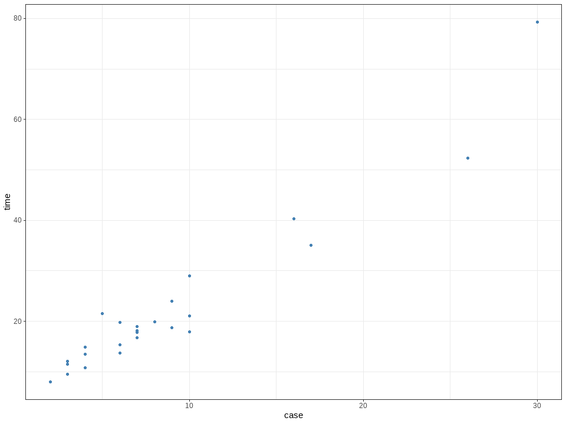

```r
dist %>%
  ggplot(aes(case, time)) +
  geom_point(color = sbl) +
  theme_bw()
```

- (case, time)의 관계는 직선의 경향을 갖는다.
- 회귀 분석의 실행

```r
dist_fit <- lm(time ~ case, data = dist)
```

- 분석 결과 확인

```r
summary(dist_fit)
```

```
##
## Call:
## lm(formula = time ~ case, data = dist)
##
## Residuals:
##    Min     1Q Median     3Q    Max
## -7.581 -1.874 -0.349  2.181 10.634
##
## Coefficients:
##             Estimate Std. Error t value           Pr(>|t|)
## (Intercept)    3.321      1.371    2.42              0.024 *
## case           2.176      0.124   17.55 0.0000000000000082 ***
## ---
## Signif. codes:  0 '***' 0.001 '**' 0.01 '*' 0.05 '.' 0.1 ' ' 1
##
## Residual standard error: 4.18 on 23 degrees of freedom
## Multiple R-squared:  0.93,   Adjusted R-squared:  0.927
## F-statistic:  308 on 1 and 23 DF,  p-value: 0.00000000000000822
```

- p-value = 0.00000000000000822 < $\alpha = 0.05$ 이므로 $H_{0}$를 기각한다.
  - 회귀 모형은 유의하다.
- `case`회귀 계수 또한 p-value < $\alpha = 0.05$로 유의하다.
- 현재 모형의 설명력은 0.93으로 높은 편이다.
- 회귀계수 확인

```r
summary(dist_fit)$coefficients
```

```
##             Estimate Std. Error t value            Pr(>|t|)
## (Intercept)     3.32      1.371    2.42 0.02372108174660464
## case            2.18      0.124   17.55 0.00000000000000822
```

- 잔차 확인

```r
summary(dist_fit)$residuals
```

```
##      1      2      3      4      5      6      7      8      9     10
## -1.874  1.651  2.181  2.855 -2.628 -0.444  0.327 -0.724 10.634  7.298
##     11     12     13     14     15     16     17     18     19     20
##  2.191 -4.082  1.475  3.372  1.094  3.918 -1.028  0.446 -0.349 -5.216
##     21     22     23     24     25
## -7.182 -7.581 -4.156 -0.900 -1.275
```

- `coef()`, `fitted()`, `resid()`: 회귀 계수, 추정값, 잔차 확인 가능

```r
coef(dist_fit) #추정된 회귀 계수 추출
```

```
## (Intercept)        case
##        3.32        2.18
```

```r
fitted(dist_fit) #현재 데이터를 이용한 추정값
```

```
##     1     2     3     4     5     6     7     8     9    10    11    12
## 18.55  9.85  9.85 12.03 16.38 18.55  7.67 18.55 68.61 14.20 38.14 25.08
##    13    14    15    16    17    18    19    20    21    22    23    24
## 12.03 16.38 22.91 25.08 16.38 18.55  9.85 40.32 25.08 59.90 22.91 20.73
##    25
## 12.03
```

```r
resid(dist_fit) #잔차
```

```
##      1      2      3      4      5      6      7      8      9     10
## -1.874  1.651  2.181  2.855 -2.628 -0.444  0.327 -0.724 10.634  7.298
##     11     12     13     14     15     16     17     18     19     20
##  2.191 -4.082  1.475  3.372  1.094  3.918 -1.028  0.446 -0.349 -5.216
##     21     22     23     24     25
## -7.182 -7.581 -4.156 -0.900 -1.275
```

- 표준화 잔차의 절대값이 2보다 크거나 같은 경우만을 선택

```r
rsd <- rstandard(dist_fit)
outliers_d <- as.numeric(names(rsd)[abs(rsd) >= 2])
dist[outliers_d, ]
```

```
##    time case distance
## 9  79.2   30      730
## 22 52.3   26      405
```

```r
dist_1 <- dist[-outliers_d, ]
```

- 스튜던트화 잔차의 절대값이 3보다 크거나 같은 경우만을 선택

```r
rst <- rstudent(dist_fit)
outliers_t <- as.numeric(names(rst)[abs(rst) >= 3])
dist[outliers_t, ]
```

```
##   time case distance
## 9 79.2   30      730
```

- $R^2_{pred}$의 계산

```r
PRESS <- sum(rstandard(dist_fit, type="pred")^2)
SST <- sum((dist$time - mean(dist$time))^2)
r.sq.p <- 1-(PRESS/SST)
paste("predicted R^2 = ", round(r.sq.p, 2))
```

```
## [1] "predicted R^2 =  0.87"
```

- 잔차 그림

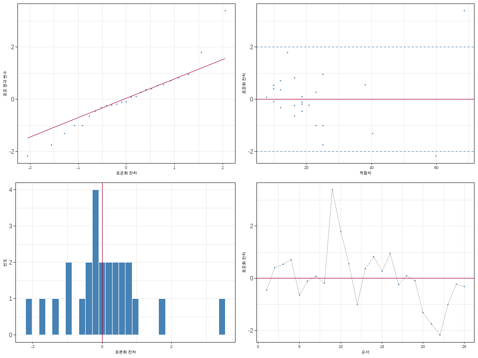

```r
rsd <- rstandard(dist_fit)
fit <- fitted.values(dist_fit)
dist_after <- cbind(dist, rsd, fit)

m_residuals(dist_after)
```

- 모형 적합 후 표준화 잔차와 적합치를 보완한 뒤에 잔차 분석`m_residuals(df)`을 실행
- `geom_smooth()`는 사전 분석 없이 기본 그림에 추정된 회귀식을 함께 도시해준다.

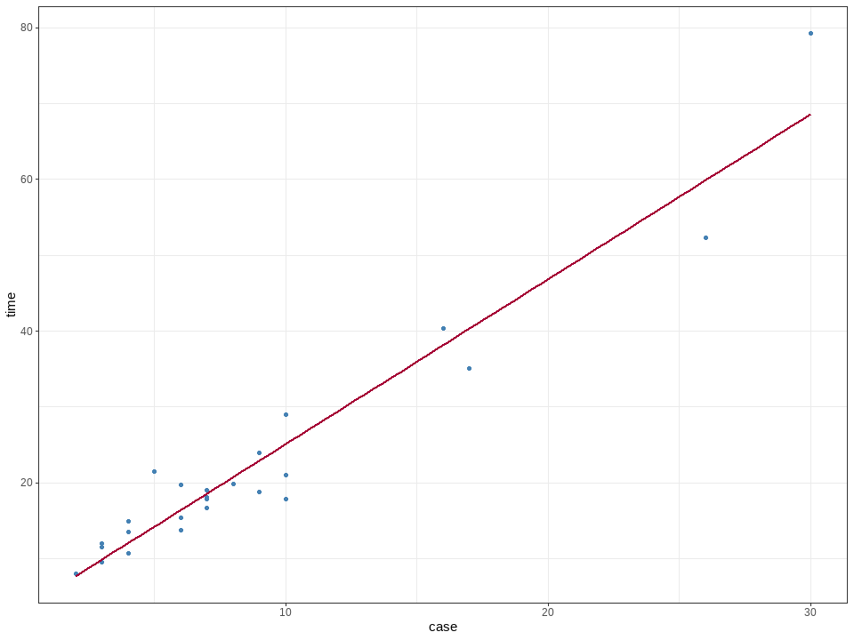

```r
dist %>%
  ggplot(aes(x = case, y = time)) +
  geom_point(color = sbl) +
  stat_smooth(method = "lm",
              formula = y~x,
              se = FALSE,
              color = lre
              ) +
  theme_bw()
```

- 평균 반응값의 구간 추정

```r
new_case <- data.frame(case = c(20, 30))
predict(dist_fit, newdata = new_case,
        interval = c("confidence"), level = 0.95)
```

```
##    fit  lwr  upr
## 1 46.8 43.5 50.2
## 2 68.6 62.9 74.3
```

- 새로운 관찰값에 대한 평균 반응값의 구간 추정

```r
new_case <- data.frame(case = c(20, 30))
predict(dist_fit, newdata = new_case,
        interval = c("prediction"), level = 0.95)
```

```
##    fit  lwr  upr
## 1 46.8 37.6 56.1
## 2 68.6 58.2 79.0
```

- 신뢰대(confidence bands)와 예측대(prediction bands)
  - ggfortify::는 통계 분석 결과를 시각화해주는 다양한 도구를 제공

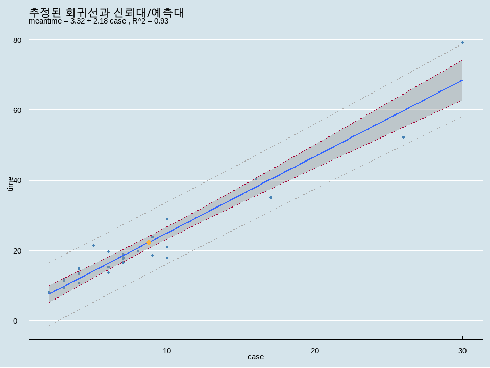

```r
# ggfortify 패키지 설치 및 불러오기
# install.packages("ggfortify")
library(ggfortify)
library(ggthemes)

# 데이터 생성
case_grid <- seq(min(dist$case), max(dist$case), by = 0.01)

# 신뢰구간(confidence bands) 예측
dist_c_band <- predict(dist_fit,
                       newdata = data.frame(case = case_grid),
                       interval = "confidence", level = 0.95)

# 예측구간(prediction bands) 예측
dist_p_band <- predict(dist_fit,
                       newdata = data.frame(case = case_grid),
                       interval = "prediction", level = 0.95)

# 그래프 그리기
ggplot(dist_fit, aes(x = case, y = time)) +
  geom_point(color = sbl) +
  geom_smooth(method = lm, se = TRUE) + # se=TRUE를 선택하여 신뢰 구간을 표시할 수 있다.
  geom_point(aes(x = mean(case), y = mean(time)),
             color = lgo,
             size = 3) +
  geom_line(data = dist_c_band,
            aes(x = case_grid, y = lwr),
            color = lre, linetype = "dashed") +
  geom_line(data = dist_c_band,
            aes(x = case_grid, y = upr),
            color = lre, linetype = "dashed") +
  geom_line(data = dist_p_band,
            aes(x = case_grid, y = lwr),
            color = "darkgray", linetype = "dashed") +
  geom_line(data = dist_p_band,
            aes(x = case_grid, y = upr),
            color = "darkgray", linetype = "dashed") +
  labs(title = "추정된 회귀선과 신뢰대/예측대",
       subtitle = paste("meantime =", round(dist_fit$coefficients[1], 2),
                        "+", round(dist_fit$coefficients[2], 2), "case",
                        ", R^2 =", round(summary(dist_fit)$r.squared, 2))) +
  theme_economist() +
  scale_color_economist()
```

- `case`에 따라 `time`이 어떻게 변화하는지를 나타내는 회귀선이다.
- `case`값이 1씩 증가할때마다 `time`이 2.18단위로 증가한다는 것을 의미한다.
- 결정계수값도 0.93으로 높은 값이라고 볼 수 있다.
  - `case`와 `time`사이에는 선형 관계가 있어보이고, 회귀식은 잘 적합되어 있어 보인다.
- 예측대 내에 데이터가 잘 들어와 있는 것으로 모아 모델이 잘 적합되어 있다.

## 실습 19. Test Case Determination

- test.sw.csv
- 00전자의 SWD팀은 최근 개발된 모델들을 중심으로 “KLOC”에 따른 적절한 ’Test Case’의 수에 대한 기준을 결정하기 위하여 기존 개발된 모델에서 두 변수간 밀접한 관계가 있는지를 확인하고, 이에 대한 모형을 설정하고자 한다.
  - 각 변수의 결측값(NA)의 수를 확인하시오.
  - 단순 회귀 모형을 가정하고 회귀 계수의 유의성 검정 결과를 제시하시오.
  - 결정 계수의 값을 제시하시오.
  - 잔차 진단을 실시하고 이상점 유무를 확인하시오.
  - 신뢰대와 예측대를 포함하여 단순 회귀 분석의 결과를 요약하시오.
- 데이터 불러오기

```r
swtest <- read.csv(paste0(data_path, "test.sw.csv"))
```

- 사용자 정의 함수 적용(단순 회귀 분석)

```r
swtest <- data.pre(swtest)
```

- 분석을 용이하게 하기 위하여 변수명을 소문자로 변환하였다.
- 잔차 진단

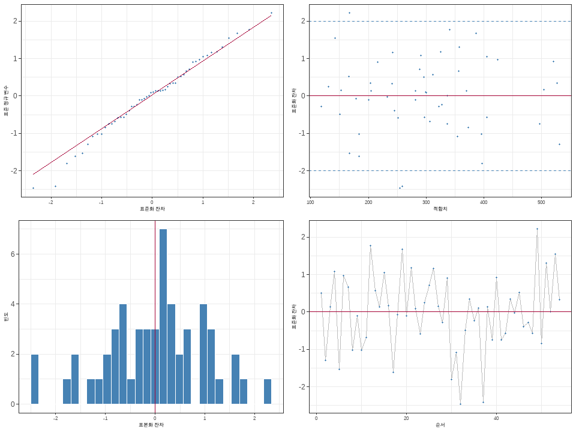

```r
swtest_fit <- lm(ttcase ~ kloc, data = swtest)

rsd <- rstandard(swtest_fit)
fit <- fitted.values(swtest_fit)
swtest_after <- cbind(swtest, rsd, fit)
m_residuals(swtest_after)
```

- 일부 양끝단을 제외하고는 정규성을 만족하는 것으으로 보인다.
- 정규성 검정 test

```r
ad.test(swtest_after$rsd)
```

```
##
##  Anderson-Darling normality test
##
## data:  swtest_after$rsd
## A = 0.2, p-value = 0.9
```

```r
pearson.test(swtest_after$rsd)
```

```
##
##  Pearson chi-square normality test
##
## data:  swtest_after$rsd
## P = 6, p-value = 0.5
```

```r
ks.test(swtest_after$rsd, "pnorm")
```

```
##
##  Exact one-sample Kolmogorov-Smirnov test
##
## data:  swtest_after$rsd
## D = 0.07, p-value = 0.9
## alternative hypothesis: two-sided
```

- 세가지의 정규성 테스트를 해본 결과 p-value > $\alpha = 0.05$ 이므로 $H_{0}$를 기각하지 못하였다.
  - 데이터는 정규성을 만족하는 것으로 보인다.
- 단순 회귀 분석 결과

```r
simple_reg(data = swtest, swtest$kloc, swtest$ttcase)
```

```
##      id  ttcase    kloc nesting  module   model
##       0       0       0       0       0       0
##
## Call:
## lm(formula = y ~ x, data = data)
##
## Residuals:
##     Min      1Q  Median      3Q     Max
## -145.55  -34.10    5.46   37.90  129.20
##
## Coefficients:
##             Estimate Std. Error t value             Pr(>|t|)
## (Intercept)  102.380     16.991    6.03           0.00000018 ***
## x             11.107      0.852   13.04 < 0.0000000000000002 ***
## ---
## Signif. codes:  0 '***' 0.001 '**' 0.01 '*' 0.05 '.' 0.1 ' ' 1
##
## Residual standard error: 59.7 on 52 degrees of freedom
## Multiple R-squared:  0.766,  Adjusted R-squared:  0.761
## F-statistic:  170 on 1 and 52 DF,  p-value: <0.0000000000000002
```

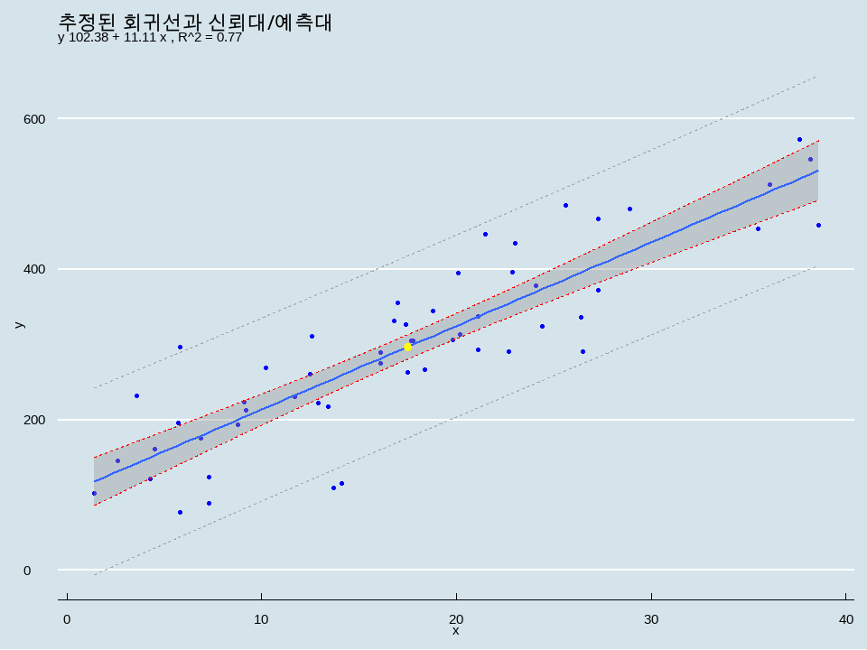

- 결측치는 존재하지 않는다.
- 결정계수값은 0.766로 잘 적합하고 있다고 볼 수 있다.
- p-value = 0.0000000000000002 < $\alpha = 0.05$ 이므로 $H_{0}$를 기각하므로 통계적으로 유의하다.
  - 위 회귀모형은 적절하다.
- 신뢰대는 빨간색 점선으로 회귀선의 평균값에 대한 신뢰도를 나타낸다.
  - 이는 회귀선의 평균값이 얼마나 정확한지를 의미한다.
- 예측대를 확인해봤을 때 모델이 데이터를 잘 반영하고 있다고 볼 수 있다.

# 5. 다중 회귀 분석

Multiple Regression Analysis

## 5.1. 최소 제곱법과 중요 결과

$$\arg
\min_{\beta_0,\beta_1,\beta_2,...,\beta_{p-1}}
L(\beta_0,\beta_1,\beta_2,...,\beta_{p-1})$$

여기서,

$$L
(\beta_0,\beta_1,\beta_2,...,\beta_{p-1}) = \sum_{i=1}^{n} (y_i -
\beta_0 - \beta_1 x_{i1} - \beta_2 x_{i2} - ... - \beta_{(p-1)}
x_{i(p-1)})^2$$
$$= (y - X\beta)^T (y
- X\beta)$$

- 회귀 계수의 LS추정량

$$\hat{\beta} = (X^T X)^{-1} X^T
y$$
$$E(\hat{\beta}) = \beta \quad
\text{그리고} \quad Var(\hat{\beta}) = \sigma^2 (X^T
X)^{-1}$$

- 반응값의 추정량과 잔차

$$\hat{y} = X\hat{\beta}, \quad e = y -
\hat{y} \quad$$
$$\quad \hat{y} =
E(y|X) = X \hat{\beta} = X(X^T X)^{-1} X^T y$$

- $\sigma^2$의 추정량 $s^2_{e}$

$$s^2_{e} = \frac{1}{n-p} \sum_{i=1}^{n}
(y_i - \hat{y}_i)^2 = \frac{e^T e}{n-p}$$

## 5.2. 변수 선택

Variable Selection

- 예측자(predictors)에 대한 사전 정보가 부족하여 적절한 예측자를 선정하지 못하거나
- 수집된 데이터에서 예측자가 많은 경우 적용
- AIC, BIC 모두 값이 작을수록 바람직하다.
  - AIC; Akike Information Criterion
  - BIC; Bayesian Information Criterion
- 2개 이상의 후보 모형을 선정하고, 잔차 분석 등의 추가 진단을 통하여 최종 모형을 선택한다.
  - **memisc::mtable()**: 모형의 비교 결과를 요약
- Mallow’s $C_{p}$
  - 회귀 모델 선택에서 사용되는 통계량
  - 여러 후보 회귀 모델 중에서 가장 적절한 모델을 선택하기 위한 기준으로 사용
  - 이 지표도 작을수록 잘 적합했다고 볼 수 있다.

### 5.2.1. 전방 선택

Foreward Selection

- 상수 모형에서 기여도가 큰 순서대로 Predictor들을 차례로 선택한다.
- 전 단계에서 모형에 포함된 Predictor들은 계속 모형에 남게 된다.
- 예측자(predictors) 들의 나열 순서는 영향을 주지 않는다.
  - **stat::step**은 AIC를 기준으로 변수를 선택한다.
  - BIC를 기준으로 변수를 선택하고자 하는 경우, k = long(n)을 옵션에 추가한다.
  - 전방 선택(direction = “forward”)의 경우, 시작 모형을 지정해야 한다.
  - 상수 모형인 경우 y ~ 1 그리고 반드시 포함해야 할 예측자가 있는 경우, y ~ x1 + x2..로 지정하여 사용한다.

### 5.2.2. 후방 제거

Backward Elimination

- 완전 모형에서 가장 기여도가 작은 순서대로 Predictor들을 차례로 제거한다.
- 전 단계에서 모형에서 제거된 예측자들은 모형에 다시 포함될 수 없다.
  - 후방 제거(direction = “backward”)의 경우, full model에서 시작하므로 시작 모형을 지정하지 않는다.

### 5.2.3. 단계별 선택

Stepwise Selection

- 후방 소거의 개념을 포함하는 전방 선택법으로 각 예측자들을 선택한 다음에 제거될 필요가 있는 예측자들을 검토하여 제거한다.
- 일단 모형에 포함된 예측자들도 다시 모형에서 제거될 수 있다.
- 단계적 선택법은 후방제거를 보완한 전방 선택법이다. 따라서 시작 모형을 반드시 지정해야 한다.

### 5.2.4. 모든 부분 집합

- 모든 가능한 회귀 모형을 적합하고, 예측자의 수에 따라 1개의 좋은 모형을 나열해 준다.
- 특정 모형을 지정해 주지 않는다.
  - **regsubsets()**을 이용하여 모든 부분 집합에 대한 회귀 모형을 고려한다.
    - 여기서, nvmax = k는 검토할 부분 집합의 최대값이다.

## 실습 20. C-materials

- cem.materials.csv
- 다음은 C-material의 구성 선분에 따른 발생 열량 관계를 분석하고자 조사된 데이터이다.
- 먼저 열량에 중요한 영향을 주는 구성 성분을 구별해 내고, 이를 통하여 발생 열량의 정도를 추정할 수 있다면, 응고 시간을 예측할 수 있어 조립 절차를 크게 간소화 할 수 있다고 한다.
- 구성 성분을 조절하여 실험하기에는 시간과 비용이 만힝 소요되어, 상대적으로 변동이 큰 표본들을 구분하여 총 4가지의 구성 성분(t1, t2, t3, t4)을 수집하였다.
- 반응값은 C-material 1g 내의 열량을 나타낸다.
- 데이터 불러오기

```r
cem <- read.csv(paste0(data_path,"cem.materials.csv"))
str(cem)
```

```
## 'data.frame':    13 obs. of  6 variables:
##  $ ID: int  1 2 3 4 5 6 7 8 9 10 ...
##  $ T1: int  7 1 11 11 7 11 3 1 2 21 ...
##  $ T2: int  26 29 56 31 52 55 71 31 54 47 ...
##  $ T3: int  6 15 8 8 6 9 17 22 18 4 ...
##  $ T4: int  60 52 20 47 33 22 6 44 22 26 ...
##  $ Y : num  78.5 74.3 104.3 87.6 95.9 ...
```

- 변수 이름과 위치 정리

```r
cem <- cem %>%
  dplyr::rename_all(tolower) %>%
  select(-id) %>%
  relocate(y)
```

- 결측값 확인

```r
na_count(cem)
```

```
##  y t1 t2 t3 t4
##  0  0  0  0  0
```

- 데이터 시각화: 행렬도(matrix plot)
  - lower는 matrix plot의 lower triangle을 말하고 upper는 upper triangle을 말한다.
  - point, smooth, cor(relation)을 선택 가능
  - diag는 대각 요소를 말함
  - densityDiag, barDiag, blankDiag를 선택 가능

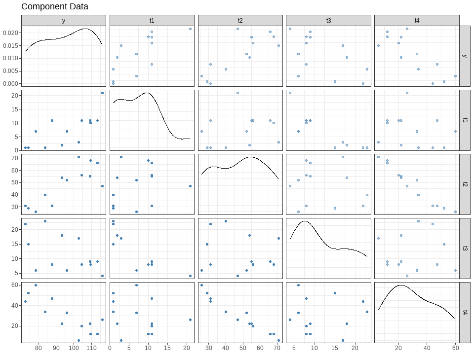

```r
cem %>%
  ggpairs(columns = 1:ncol(.),
          lower = list(continuous = wrap("points", # continuous = "smooth"
                                         color = sbl,
                                         aplha = 0.5)
                   ),
          upper = list(continuous = wrap("points", # wrap("cor", size = 2.5)
                                         color = sbl,
                                         alpha =0.5)
                   ),
          diag = list(continuous = wrap("densityDiag",
                                        color = "black",
                                        alpha = 0.5)
                   ),
          title = "Component Data") +
  theme_bw()
```

- 함수 정의
  - 원하는 형태의 행렬도(matrix plot) 형식을 결정하여 함수화
  - `gg_mplot(data, title)`

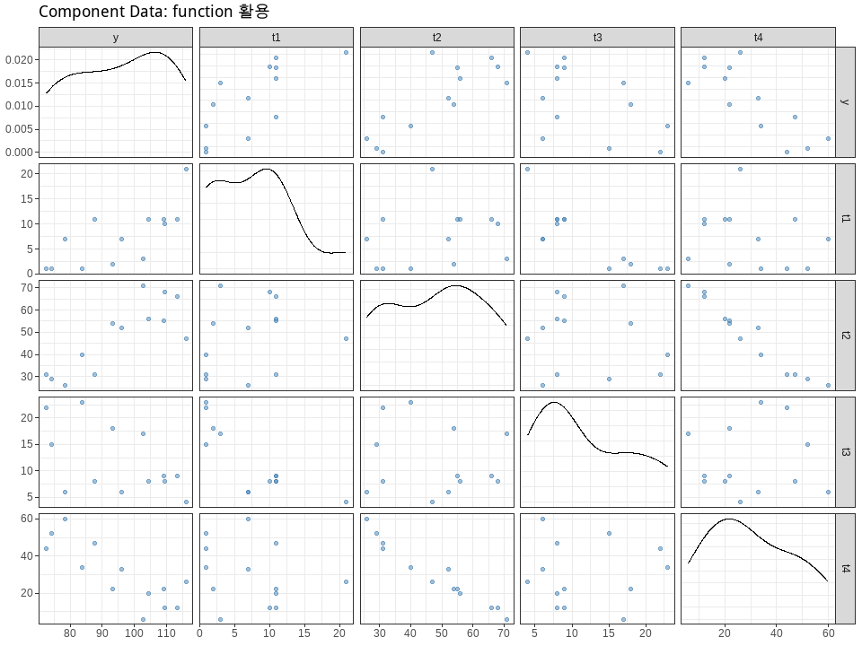

```r
gg_mplot <- function(df, ttl){
  df %>%
  ggpairs(columns = 1:ncol(.),
          lower = list(continuous = wrap("points", #continuous = "smooth"
                                         color = sbl,
                                         alpha = 0.5)
                       ),
          upper = list(continuous = wrap("points", #wrap("cor", size = 2.5)
                                         color = sbl,
                                         alpha = 0.5)
                       ),
          diag = list(continuous = wrap("densityDiag",
                                        color = "black",
                                        alpha = 0.5)
                       ),
          title = ttl) +
  theme_bw()
}

ttl = "Component Data: function 활용"
gg_mplot(cem, ttl)
```

- 다중 회귀 분석: **lm()*
  - **lm()* 함수는 단순 회귀 분석과 동일하게 적용된다.
  - 단, formula를 사전에 지정하는 경우에는 문자형으로 정의되어야 한다.

```r
fml <- "y ~ t1 + t2 + t3 + t4"
cem_model <- lm(fml, cem)
summary(cem_model)
```

```
##
## Call:
## lm(formula = fml, data = cem)
##
## Residuals:
##    Min     1Q Median     3Q    Max
## -3.175 -1.671  0.251  1.378  3.925
##
## Coefficients:
##             Estimate Std. Error t value Pr(>|t|)
## (Intercept)   62.405     70.071    0.89    0.399
## t1             1.551      0.745    2.08    0.071 .
## t2             0.510      0.724    0.70    0.501
## t3             0.102      0.755    0.14    0.896
## t4            -0.144      0.709   -0.20    0.844
## ---
## Signif. codes:  0 '***' 0.001 '**' 0.01 '*' 0.05 '.' 0.1 ' ' 1
##
## Residual standard error: 2.45 on 8 degrees of freedom
## Multiple R-squared:  0.982,  Adjusted R-squared:  0.974
## F-statistic:  111 on 4 and 8 DF,  p-value: 0.000000476
```

- 모든 변수가 유의하지 않지만, $R^2 = 0.982$이다.
- 회귀 분석 관련 추정값 추출

```r
cem_model$coefficients
```

```
## (Intercept)          t1          t2          t3          t4
##      62.405       1.551       0.510       0.102      -0.144
```

```r
summary(cem_model)$sigma
```

```
## [1] 2.45
```

- 구간 추정
  - lm()에 의한 model object가 생성
    - 신뢰도(level = )하에서 **stat::confint()**를 이용하여 개별 회귀 계수에 대한 구간 추정 결과를 확인
    - **conflict()**의 기본 함수 구조
      - 특정 회귀 계수(들)만을 원하는 경우, parm의 위치에 문자형으로 지정

```r
confint(cem_model, level = 0.95)
```

```
##               2.5 % 97.5 %
## (Intercept) -99.179 223.99
## t1           -0.166   3.27
## t2           -1.159   2.18
## t3           -1.638   1.84
## t4           -1.779   1.49
```

```r
confint(cem_model, c("t1", "t2"), level = 0.95)
```

```
##     2.5 % 97.5 %
## t1 -0.166   3.27
## t2 -1.159   2.18
```

- 가설 검정
  - lm()을 적용한 model object의 summary()의 coef를 부분 선택

```r
summary(cem_model)$coef
```

```
##             Estimate Std. Error t value Pr(>|t|)
## (Intercept)   62.405     70.071   0.891   0.3991
## t1             1.551      0.745   2.083   0.0708
## t2             0.510      0.724   0.705   0.5009
## t3             0.102      0.755   0.135   0.8959
## t4            -0.144      0.709  -0.203   0.8441
```

- 예측 구간 - **stat::predict()**:model object(class = lm)를 이용하여 점 추정과 구간 추정을 실행
  - interval = c(“none”, “confidence”, “prediction”)
  - **“confidence”**는 평균 반응값에 대한 신뢰구간을 제공
  - **“prediction”**은 새로운 관찰값에서의 반응값에 대한 신뢰구간을 제공

```r
x0 <- data.frame(t1 = 11, t2 =56, t3 = 9, t4 = 20)
```

```r
#점추정
predict(cem_model, newdata = x0)
```

```
##   1
## 106
```

```r
#구간 추정: 신뢰 구간
predict(cem_model, newdata = x0, interval = "confidence", level = 0.95)
```

```
##   fit lwr upr
## 1 106 103 109
```

```r
#구간 추정: 예측 구간
predict(cem_model, newdata = x0, interval = "prediction", level = 0.95)
```

```
##   fit  lwr upr
## 1 106 99.7 112
```

### 변수 선택 실습

- 전방 선택법, 후방제거법, 단계별 선택법, 모든 부분 집합법

#### 전방 선택

- 선택 과정의 정보를 생략하고 최종 경과만을 확인하고 싶으면 trace = 0 옵션을 추가한다.

```r
# fml <- "y ~ t1 + t2 + t3+ t4"
model_start <- lm(y ~ 1, data = cem)
cem_fore_aic <- step(model_start, scope = fml, diretion = "forward")
```

```
## Start:  AIC=71.4
## y ~ 1
##
##        Df Sum of Sq  RSS  AIC
## + t4    1      1832  884 58.9
## + t2    1      1809  906 59.2
## + t1    1      1450 1266 63.5
## + t3    1       776 1939 69.1
## <none>              2716 71.4
##
## Step:  AIC=58.9
## y ~ t4
##
##        Df Sum of Sq  RSS  AIC
## + t1    1       809   75 28.7
## + t3    1       708  176 39.9
## <none>               884 58.9
## + t2    1        15  869 60.6
## - t4    1      1832 2716 71.4
##
## Step:  AIC=28.7
## y ~ t4 + t1
##
##        Df Sum of Sq  RSS  AIC
## + t2    1        27   48 25.0
## + t3    1        24   51 25.7
## <none>                75 28.7
## - t1    1       809  884 58.9
## - t4    1      1191 1266 63.5
##
## Step:  AIC=25
## y ~ t4 + t1 + t2
##
##        Df Sum of Sq RSS  AIC
## <none>               48 25.0
## - t4    1        10  58 25.4
## + t3    1         0  48 26.9
## - t2    1        27  75 28.7
## - t1    1       821 869 60.6
```

- 최종 선택된 모형의 회귀 계수의 수(p)와 AIC 제공

```r
extractAIC(cem_fore_aic)
```

```
## [1]  4 25
```

- 추정된 회귀 계수들

```r
coef(cem_fore_aic)
```

```
## (Intercept)          t4          t1          t2
##      71.648      -0.237       1.452       0.416
```

- Adj $R^2$

```r
summary(cem_fore_aic)$adj.r.squared
```

```
## [1] 0.976
```

- BIC

```r
cem_fore_bic <- step(model_start, scope = fml, direction = "forward",
                     k = log(length(cem)),
                     trace = 0)
coef(cem_fore_bic)
```

```
## (Intercept)          t4          t1          t2
##      71.648      -0.237       1.452       0.416
```

- Adj $R^2$

```r
summary(cem_fore_bic)$adj.r.squared
```

```
## [1] 0.976
```

- 최종 모형의 formula확인

```r
formula(cem_fore_bic)
```

```
## y ~ t4 + t1 + t2
```

#### 후방 제거

- full model에서 시작하기 때문에 시작 모형을 지정하지 않는다.
- AIC

```r
cem_back_aic <- step(cem_model, direction = "backward", trace = 0)
extractAIC(cem_back_aic)
```

```
## [1]  4 25
```

```r
coef(cem_back_aic)
```

```
## (Intercept)          t1          t2          t4
##      71.648       1.452       0.416      -0.237
```

- AIC를 기준으로 최종 모형의 formula

```r
formula(cem_back_aic)
```

```
## y ~ t1 + t2 + t4
## <environment: 0x0000012782283700>
```

- BIC

```r
n <- length(resid(cem_model))
```

```r
cem_back_bic <- step(cem_model, direction = "backward",
                     k = log(n),
                     trace = 0)
coef(cem_back_bic)
```

```
## (Intercept)          t1          t2
##      52.577       1.468       0.662
```

- BIC를 기준으로 최종 모형의 formula

```r
formula(cem_back_bic)
```

```
## y ~ t1 + t2
## <environment: 0x0000012782283700>
```

#### 단계별 선택

- 시작 모형을 반드시 지정해야 한다.

```r
cem_both_aic <- step(model_start, scope = fml, diretion = "both", trace = 0)
cem_both_bic <- step(model_start, scope = fml, diretion = "both",
                     k = log(n),
                     trace = 0)
```

- 단계별 선택법에 의하여 선택된 최종 모형의 formula

```r
formula(cem_both_aic)
```

```
## y ~ t4 + t1 + t2
```

- AIC와 BIC기준으로 각각의 변수 선택 방법에 의하여 도출된 최종 모형을 비교

```r
final.model_aic <- rbind("forward" = as.character(formula(cem_fore_aic))[3],
                         "backward" = as.character(formula(cem_back_aic))[3],
                         "stepwise" = as.character(formula(cem_both_aic))[3]
                         )
final.model_bic <- rbind("forward" = as.character(formula(cem_fore_bic))[3],
                         "backward" = as.character(formula(cem_back_bic))[3],
                         "stepwise" = as.character(formula(cem_both_bic))[3]
                         )
info <- cbind(final.model_aic, final.model_bic)
colnames(info) <- c("AIC", "BIC")
info
```

```
##          AIC            BIC
## forward  "t4 + t1 + t2" "t4 + t1 + t2"
## backward "t1 + t2 + t4" "t1 + t2"
## stepwise "t4 + t1 + t2" "t1 + t2"
```

- AIC에 기초하여 선택된 모형의 예측자는 3가지 방법 모두 (t1, t2, t4)로 동일하다.
- BIC에 기초하여 선택된 예측자는 (t1, t2, t4)와 (t1, t2)이다.
- 결과가 비슷하다면, 가능한 한 간단한 모형을 선택하는 것이 바람직하다.
- AIC에 의하여 선택된 최종 모형의 결과는 다음과 같다.

```r
extractAIC(cem_fore_aic)
```

```
## [1]  4 25
```

```r
extractAIC(cem_back_aic)
```

```
## [1]  4 25
```

```r
extractAIC(cem_both_aic)
```

```
## [1]  4 25
```

```r
summary(cem_back_aic)
```

```
##
## Call:
## lm(formula = y ~ t1 + t2 + t4, data = cem)
##
## Residuals:
##    Min     1Q Median     3Q    Max
## -3.092 -1.802  0.256  1.282  3.898
##
## Coefficients:
##             Estimate Std. Error t value   Pr(>|t|)
## (Intercept)   71.648     14.142    5.07    0.00068 ***
## t1             1.452      0.117   12.41 0.00000058 ***
## t2             0.416      0.186    2.24    0.05169 .
## t4            -0.237      0.173   -1.37    0.20540
## ---
## Signif. codes:  0 '***' 0.001 '**' 0.01 '*' 0.05 '.' 0.1 ' ' 1
##
## Residual standard error: 2.31 on 9 degrees of freedom
## Multiple R-squared:  0.982,  Adjusted R-squared:  0.976
## F-statistic:  167 on 3 and 9 DF,  p-value: 0.0000000332
```

- 세 가지 방법 모두 AIC가 동일하다.
- BIC도 각각의 값들을 확인을 해보았다.

```r
extractAIC(cem_fore_bic)
```

```
## [1]  4 25
```

```r
extractAIC(cem_back_bic)
```

```
## [1]  3.0 25.4
```

```r
extractAIC(cem_both_bic)
```

```
## [1]  3.0 25.4
```

- BIC에 의하여 선택된 최종 모형의 결과는 다음과 같다.

```r
summary(cem_back_bic)
```

```
##
## Call:
## lm(formula = y ~ t1 + t2, data = cem)
##
## Residuals:
##    Min     1Q Median     3Q    Max
##  -2.89  -1.57  -1.30   1.36   4.05
##
## Coefficients:
##             Estimate Std. Error t value      Pr(>|t|)
## (Intercept)  52.5773     2.2862    23.0 0.00000000055 ***
## t1            1.4683     0.1213    12.1 0.00000026922 ***
## t2            0.6623     0.0459    14.4 0.00000005029 ***
## ---
## Signif. codes:  0 '***' 0.001 '**' 0.01 '*' 0.05 '.' 0.1 ' ' 1
##
## Residual standard error: 2.41 on 10 degrees of freedom
## Multiple R-squared:  0.979,  Adjusted R-squared:  0.974
## F-statistic:  230 on 2 and 10 DF,  p-value: 0.00000000441
```

- 이 모형같은 경우에는 더 적은 변수로 회귀식을 도출할 수 있다.
- 다른 방법같은 경우에도 비슷한 BIC를 보이므로 잔차 분석을 통한 추가 분석도 고려해 볼 필요가 있다.

#### 모든 부분 집합

- `library(leaps)`
  - **regsubsets()**을 이용하여 모든 부분 집합에 대한 회귀모형을 고려한다.
    - nvmax = k는 검토할 부분집합의 최대값
  - **memisc::mtable()**: 모형의 비교 결과를 요약한다.

```r
library(leaps)

temp <- leaps(x = cem[, -1], y = cem[ , 1])
full <- as.formula(paste("y ~ ",
                         paste(colnames(cem[-1]), collapse = "+"))
                   )
cem_all <- regsubsets(full, data = cem, nvmax = 4)
summary(cem_all)
```

```
## Subset selection object
## Call: regsubsets.formula(full, data = cem, nvmax = 4)
## 4 Variables  (and intercept)
##    Forced in Forced out
## t1     FALSE      FALSE
## t2     FALSE      FALSE
## t3     FALSE      FALSE
## t4     FALSE      FALSE
## 1 subsets of each size up to 4
## Selection Algorithm: exhaustive
##          t1  t2  t3  t4
## 1  ( 1 ) " " " " " " "*"
## 2  ( 1 ) "*" "*" " " " "
## 3  ( 1 ) "*" "*" " " "*"
## 4  ( 1 ) "*" "*" "*" "*"
```

```r
model.q <- summary(cem_all)
```

모형 선택중

```r
# 수정 결정계수가 가장 큰 모형
(adj.r2 <- which.max(model.q$adjr2))
```

```
## [1] 3
```

```r
# Cp가 가장 작은 모형
(cp <- which.min(model.q$cp))
```

```
## [1] 2
```

```r
# BIC가 가장 작은 모형
(bic <- which.min(model.q$bic))
```

```
## [1] 2
```

- 2개 이상의 후보 모형을 선정하고, 잔차 분석 등의 추가 진단을 통하여 최종 모형을 선택

```r
# install.packages("memisc")

library(memisc)
model_1 <- lm(formula = y ~ t1, data = cem)
model_2 <- lm(formula = y ~ t1 + t2, data = cem)
model_3 <- lm(formula = y ~ t1 + t2 + t3, data = cem)
model_4 <- lm(formula = y ~ t1 + t2 + t3 + t4, data = cem)

s_table <- mtable("M1" = model_1, "M2" = model_2, "M3" = model_3, "M4" = model_4,
                  summary.stats = c("sigma", "R-squared", "F", "P"))
s_table
```

```
##
## Calls:
## M1: lm(formula = y ~ t1, data = cem)
## M2: lm(formula = y ~ t1 + t2, data = cem)
## M3: lm(formula = y ~ t1 + t2 + t3, data = cem)
## M4: lm(formula = y ~ t1 + t2 + t3 + t4, data = cem)
##
## ============================================================
##                   M1          M2          M3         M4
## ------------------------------------------------------------
##   (Intercept)  81.479***   52.577***   48.194***   62.405
##                (4.927)     (2.286)     (3.913)    (70.071)
##   t1            1.869**     1.468***    1.696***    1.551
##                (0.526)     (0.121)     (0.205)     (0.745)
##   t2                        0.662***    0.657***    0.510
##                            (0.046)     (0.044)     (0.724)
##   t3                                    0.250       0.102
##                                        (0.185)     (0.755)
##   t4                                               -0.144
##                                                    (0.709)
## ------------------------------------------------------------
##   sigma        10.727       2.406       2.312       2.446
##   R-squared     0.534       0.979       0.982       0.982
##   F            12.603     229.504     166.345     111.479
## ============================================================
##   Significance: *** = p < 0.001; ** = p < 0.01;
##                 * = p < 0.05
```

- $Mallow's~C_{p}$는 다음을 이용하여 계산한다.

```r
# install.packages("olsrr")
library(olsrr)
full <- as.formula(paste("y ~ ",
                         paste(colnames(cem[-1]), collapse = "+"))
                         )
full
```

```
## y ~ t1 + t2 + t3 + t4
```

```r
temp <- as.formula(paste("y ~ ",
                         paste(colnames(cem[-c(1, 5:6)]), collapse = "+"))
                   )
temp
```

```
## y ~ t1 + t2 + t3
```

```r
f_model <- lm(formula(full), data = cem)
t_model <- lm(formula(temp), data = cem)
ols_mallows_cp(t_model, f_model) # 반드시 full_model 지정
```

```
## [1] 3.04
```

- Cp결과 값이 3.04로 나왔는데, 이는 t_model의 적합도와 변수의 수를 고려할 때의 평가 결과이다.
- `t_model`의 경우 세 가지의 설명변수를 사용했는데 Cp값이 3.04가 나왔다는 건 적절하다고 보인다.
- 이번에는 BIC 모형에서의 결과인, (t1, t2)를 사용한 모형에도 적용을 해보았다.

```r
full <- as.formula(paste("y ~ ",
                         paste(colnames(cem[-1]), collapse = "+"))
                         )
full
```

```
## y ~ t1 + t2 + t3 + t4
```

```r
temp <- as.formula(paste("y ~ ",
                         paste(colnames(cem[-c(1, 4:6)]), collapse = "+"))
                   )
temp
```

```
## y ~ t1 + t2
```

```r
f_model <- lm(formula(full), data = cem)
t_model <- lm(formula(temp), data = cem)
ols_mallows_cp(t_model, f_model) # 반드시 full_model 지정
```

```
## [1] 2.68
```

# 중요한 기본 R함수 정리

- 변수명은 대문자 또는 소문자로 통일하는 것이 바람직하다.

## 데이터 확인

`str()`  
`head()`  
`tail()`  
`view()`

## 회귀 분석

`stats::lm()`: lm(y ~ x, data = data)으로 지정

- `name()`는 모형 적합 객체(object)에 포함된 구성 요소들의 이름을 확인해준다.
  - ex) model(dist_fit), model(summary(dist_fit))
- 이상점(outliers)의 진단
  - `rstandard()`: 표준화 잔차(standardized residuals)
    - 표준화 잔차의 절대값이 2보다 크거나 같은 경우만을 선택
      - rsd <- rstandard(dist_fit)
      - outliers_d <- as.numeric(names(rsd)[abs(rsd) >= 2])
      - dist[outliers_d, ]: 이상치 확인
      - dist[-outliers_d, ]: 검토 결과 이를 제거해야 한다면 다음을 이용하여 제거
  - `rstudent()`: 스튜던트화 잔차(studentized residuals)
    - 스튜던트화 잔차의 절대값이 3보다 크거나 같은 경우만을 선택
- `ggexport()`을 이용하여 생성된 plot을 원하는 위치의 외부 화일로 저장가능하다.
  - ggexport(object, filename = “./image/object.pdf”)
- `geom_smooth()`는 사전 분석 없이 기본 그림에 추정된 회귀식을 함께 도시해준다.

## 사용자 정의 함수 정리

`na_count(data)`: 결측값 확인  
`data_pre(data)`: 데이터의 변수들의 이름을 모두 소문자로 전환하는 함수  
`simple_reg(data, x, y)`: 단순 회귀 분석 최종 결과를 시각화하는 함수

ⓒ Statistical Method1, Gachon University